# Hypertension_Simulation

Hemanshu Das

5/21/2019

The Rmarkdown is an implementation of the simulation model to emulate a cohort of 50 yr old, Male, 27.7BMI Smokers with 150mmHg SBP profile through state-level transitions with constant death rate for a period of 10 years.

The intervention considered is simplistic wherein everyone in the treatment cohort has access to hypertension treatment.

```r
#Model Inputs
n.i <- 1000                             #Number of individuals
ini_age <- 50                           #Start Age of Cohort
end_age <- 60                           #Simulation End Age
cl <- 1                                 #Number of Cycle in a year
v.n <- c("W","MI","ST","postMI","postST","cD","D")        #Model States: W-Well, CVD-CVD Event, MI - Myocardial Infraction Transitory State, ST- Transitory Stroke State, cD - CVD Death, D - Death due to other causes
n.s <- length(v.n)                      #Number of model states
v.M_1 <- rep("W",n.i)                   #Everyone is Well at the start
v.Str <- c("No Treatment","Treatment")  #Storing the Strategy Indicator
n.t <- (end_age - ini_age)*12                #Simulation cycles
d.c   <- d.e <- 0                    #Equal discounting of costs and QALYs by 3%

#Initialization of Transition Probabilities (Monthly transition)
p.W_CVD <- 0.00206                  #Probability of CVD transitory event when well; 50 yr, M, Smoker, SBP 150mmHg, BMI 27.7
p.CVD_MI <- 0.188                  #Probability of MI when CVD event occurs
p.CVD_ST <- 1 - p.CVD_MI           #Probability of Stroke when CVD event occurs
p.MI_cD <- 0.335                   #Probability of fatal outcome when MI occurs
p.ST_cD <- 0.181                   #Probability of fatal outcome when Stroke occurs
p.MI_postMI <- 1 - p.MI_cD         #Probability of non-fatal outcome when MI occurs
p.ST_postST <- 1 - p.ST_cD         #Probability of non-fatal outcome when Stroke occurs
p.postMI_cD <- 0.0022*0.76              #Probability of CVD death post non-fatal MI
p.postMI_D <- 0.0022*0.24              #Probability of death post non-fatal MI
p.postST_cD <- 0.0028 *0.336             #Probability of CVD death post non-fatal ST
p.postST_D <- 0.0028 *0.664             #Probability of death post non-fatal ST
p.W_D <- 0.00054                   #Probability of normal death from any state

#Intiatlization of Cost for each state
c.W <- 1                      #cost of being well
c.MI <- 1428.57                  #cost of acute MI treatment (Assumed to be INR 1,00,000)
c.ST <- 2142.85                  #cost of acute Stroke treatment (Assumed to be INR 1,50,000)
c.postMI <- c.postST <- 28.57 #cost of follow up care (Assumed to be INR 2000 p.m)
c.D <- c.cD <- 0              #cost of Death

#Intialization of Utility for each state
u.W <- 1                      #utility of being well
u.MI <- u.postMI <- 0.76                  #utility of MI state
u.ST <- u.postST <- 0.629                 #utility of Stroke state
u.D <- u.cD <- 0              #utility of death

# If not treated
p.W_CVD_NT <- 0.00206          #15% reduction in CVD risk
c.W_NT <- 0                   #Cost of medication and consultation in a month

# If treated
p.W_CVD_T <- 0.00172          #15% reduction in CVD risk
c.W_T <- 4.57                 #Cost of medication and consultation in a month
```

# Running the simulations

```
##              CVD Events Non-CVD Deaths CVD Deaths Costs($) QALYs ICER
## No Treatment          0              0          0        0   121
## Treatment             0              0          0      553   121  Inf
```

According to WHO, if the ICER is less than thrice the GDP per Capita, the investment in the intervention should be pursued. There are alternative aproaches as well, but I haven’t explored them yet.

# Diesease transition when No Treatment is provided

```
##           Cycle 0 Cycle 1 Cycle 2 Cycle 3 Cycle 4 Cycle 5 Cycle 6 Cycle 7
## Well         1000    1000    1000    1000    1000    1000    1000    1000
## CVD Death       0       0       0       0       0       0       0       0
## Death           0       0       0       0       0       0       0       0
##           Cycle 8 Cycle 9 Cycle 10 Cycle 11 Cycle 12 Cycle 13 Cycle 14
## Well         1000    1000     1000     1000     1000     1000     1000
## CVD Death       0       0        0        0        0        0        0
## Death           0       0        0        0        0        0        0
##           Cycle 15 Cycle 16 Cycle 17 Cycle 18 Cycle 19 Cycle 20 Cycle 21
## Well          1000     1000     1000     1000     1000     1000     1000
## CVD Death        0        0        0        0        0        0        0
## Death            0        0        0        0        0        0        0
##           Cycle 22 Cycle 23 Cycle 24 Cycle 25 Cycle 26 Cycle 27 Cycle 28
## Well          1000     1000     1000     1000     1000     1000     1000
## CVD Death        0        0        0        0        0        0        0
## Death            0        0        0        0        0        0        0
##           Cycle 29 Cycle 30 Cycle 31 Cycle 32 Cycle 33 Cycle 34 Cycle 35
## Well          1000     1000     1000     1000     1000     1000     1000
## CVD Death        0        0        0        0        0        0        0
## Death            0        0        0        0        0        0        0
##           Cycle 36 Cycle 37 Cycle 38 Cycle 39 Cycle 40 Cycle 41 Cycle 42
## Well          1000     1000     1000     1000     1000     1000     1000
## CVD Death        0        0        0        0        0        0        0
## Death            0        0        0        0        0        0        0
##           Cycle 43 Cycle 44 Cycle 45 Cycle 46 Cycle 47 Cycle 48 Cycle 49
## Well          1000     1000     1000     1000     1000     1000     1000
## CVD Death        0        0        0        0        0        0        0
## Death            0        0        0        0        0        0        0
##           Cycle 50 Cycle 51 Cycle 52 Cycle 53 Cycle 54 Cycle 55 Cycle 56
## Well          1000     1000     1000     1000     1000     1000     1000
## CVD Death        0        0        0        0        0        0        0
## Death            0        0        0        0        0        0        0
##           Cycle 57 Cycle 58 Cycle 59 Cycle 60 Cycle 61 Cycle 62 Cycle 63
## Well          1000     1000     1000     1000     1000     1000     1000
## CVD Death        0        0        0        0        0        0        0
## Death            0        0        0        0        0        0        0
##           Cycle 64 Cycle 65 Cycle 66 Cycle 67 Cycle 68 Cycle 69 Cycle 70
## Well          1000     1000     1000     1000     1000     1000     1000
## CVD Death        0        0        0        0        0        0        0
## Death            0        0        0        0        0        0        0
```

[output cut: 17 more lines]

```
## Well          1000      1000      1000      1000      1000      1000
## CVD Death        0         0         0         0         0         0
## Death            0         0         0         0         0         0
##           Cycle 105 Cycle 106 Cycle 107 Cycle 108 Cycle 109 Cycle 110
## Well           1000      1000      1000      1000      1000      1000
## CVD Death         0         0         0         0         0         0
## Death             0         0         0         0         0         0
##           Cycle 111 Cycle 112 Cycle 113 Cycle 114 Cycle 115 Cycle 116
## Well           1000      1000      1000      1000      1000      1000
## CVD Death         0         0         0         0         0         0
## Death             0         0         0         0         0         0
##           Cycle 117 Cycle 118 Cycle 119 Cycle 120
## Well           1000      1000      1000      1000
## CVD Death         0         0         0         0
## Death             0         0         0         0
```

# Diesease transition when Treatment is provided

```
##           Cycle 0 Cycle 1 Cycle 2 Cycle 3 Cycle 4 Cycle 5 Cycle 6 Cycle 7
## Well         1000    1000    1000    1000    1000    1000    1000    1000
## CVD Death       0       0       0       0       0       0       0       0
## Death           0       0       0       0       0       0       0       0
##           Cycle 8 Cycle 9 Cycle 10 Cycle 11 Cycle 12 Cycle 13 Cycle 14
## Well         1000    1000     1000     1000     1000     1000     1000
## CVD Death       0       0        0        0        0        0        0
## Death           0       0        0        0        0        0        0
##           Cycle 15 Cycle 16 Cycle 17 Cycle 18 Cycle 19 Cycle 20 Cycle 21
## Well          1000     1000     1000     1000     1000     1000     1000
## CVD Death        0        0        0        0        0        0        0
## Death            0        0        0        0        0        0        0
##           Cycle 22 Cycle 23 Cycle 24 Cycle 25 Cycle 26 Cycle 27 Cycle 28
## Well          1000     1000     1000     1000     1000     1000     1000
## CVD Death        0        0        0        0        0        0        0
## Death            0        0        0        0        0        0        0
##           Cycle 29 Cycle 30 Cycle 31 Cycle 32 Cycle 33 Cycle 34 Cycle 35
## Well          1000     1000     1000     1000     1000     1000     1000
## CVD Death        0        0        0        0        0        0        0
## Death            0        0        0        0        0        0        0
##           Cycle 36 Cycle 37 Cycle 38 Cycle 39 Cycle 40 Cycle 41 Cycle 42
## Well          1000     1000     1000     1000     1000     1000     1000
## CVD Death        0        0        0        0        0        0        0
## Death            0        0        0        0        0        0        0
##           Cycle 43 Cycle 44 Cycle 45 Cycle 46 Cycle 47 Cycle 48 Cycle 49
## Well          1000     1000     1000     1000     1000     1000     1000
## CVD Death        0        0        0        0        0        0        0
## Death            0        0        0        0        0        0        0
##           Cycle 50 Cycle 51 Cycle 52 Cycle 53 Cycle 54 Cycle 55 Cycle 56
## Well          1000     1000     1000     1000     1000     1000     1000
## CVD Death        0        0        0        0        0        0        0
## Death            0        0        0        0        0        0        0
##           Cycle 57 Cycle 58 Cycle 59 Cycle 60 Cycle 61 Cycle 62 Cycle 63
## Well          1000     1000     1000     1000     1000     1000     1000
## CVD Death        0        0        0        0        0        0        0
## Death            0        0        0        0        0        0        0
##           Cycle 64 Cycle 65 Cycle 66 Cycle 67 Cycle 68 Cycle 69 Cycle 70
## Well          1000     1000     1000     1000     1000     1000     1000
## CVD Death        0        0        0        0        0        0        0
## Death            0        0        0        0        0        0        0
```

[output cut: 17 more lines]

```
## Well          1000      1000      1000      1000      1000      1000
## CVD Death        0         0         0         0         0         0
## Death            0         0         0         0         0         0
##           Cycle 105 Cycle 106 Cycle 107 Cycle 108 Cycle 109 Cycle 110
## Well           1000      1000      1000      1000      1000      1000
## CVD Death         0         0         0         0         0         0
## Death             0         0         0         0         0         0
##           Cycle 111 Cycle 112 Cycle 113 Cycle 114 Cycle 115 Cycle 116
## Well           1000      1000      1000      1000      1000      1000
## CVD Death         0         0         0         0         0         0
## Death             0         0         0         0         0         0
##           Cycle 117 Cycle 118 Cycle 119 Cycle 120
## Well           1000      1000      1000      1000
## CVD Death         0         0         0         0
## Death             0         0         0         0
```

# Plotting the curves for Survival and CVD Deaths

Plot representing the subjects in well state with each cycle transition with “Blue” for Treatment cohort, and Red for No Treatment cohort

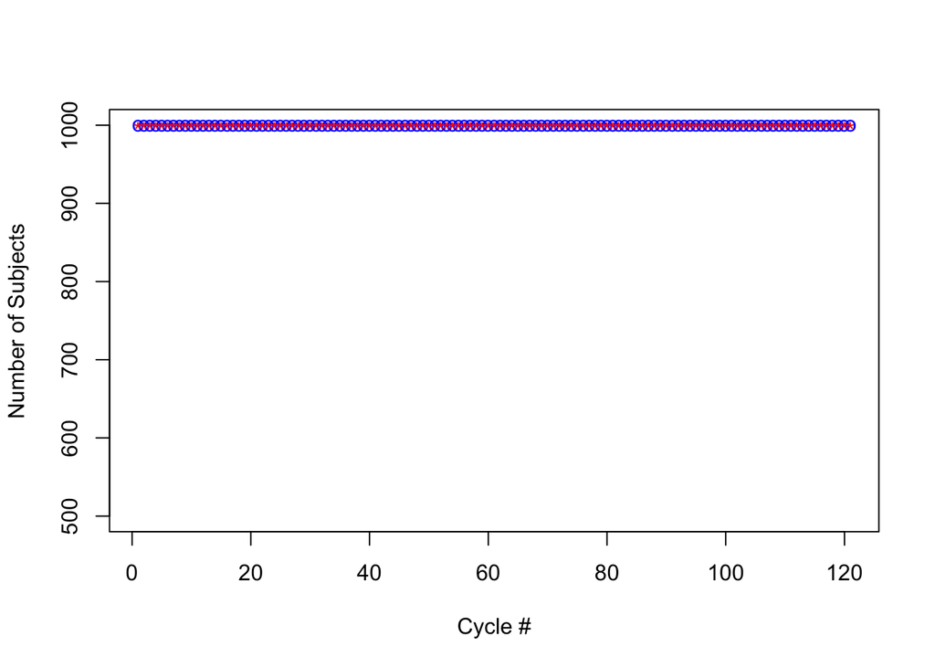

```
## integer(0)
```

Plot representing the subjects lost due to CVD deaths with each cycle transition with “Blue” for Treatment chort, and Red for No Treatment cohort

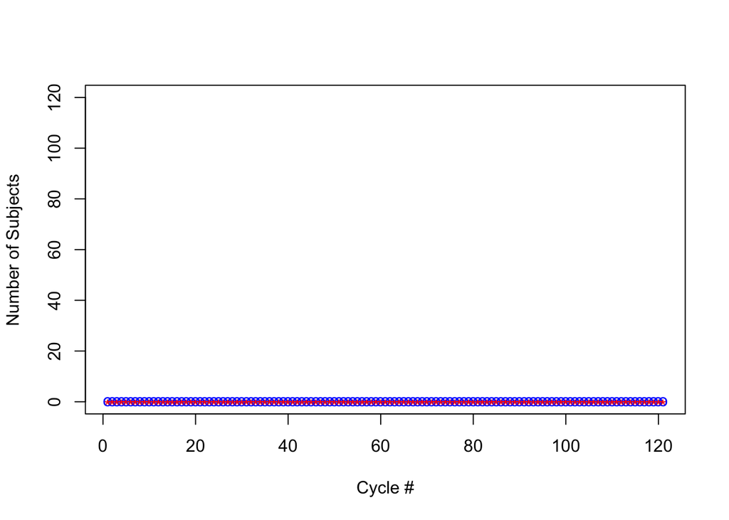

```
## integer(0)
```

```r
time_taken <- end_time - start_time
time_taken
```

```
## Time difference of 22.44796 secs
```

Limitations of the current model:  
1. The transition matrix probabilities need to be refined - We can have a detailed discussion on this  
2. The cohort should ideally be run till end of age (ie. death or age=80+ years), but I need to modify the p.W_CVD into a dynamic formula which calculates value based on the risk factor parameters for the individual  
3. The model assumes subjects to eternally stay in MI or Stroke state, and doesn’t consider movement back to Well state.